```python
%run EUVIP_1_defaults.ipynb
```

```
Range of spatial frequencies:  [ 0.618   0.382   0.2361  0.1459  0.0902  0.0557  0.0344  0.0213]
Range of angles (in degrees):  [-82.5 -75.  -67.5 -60.  -52.5 -45.  -37.5 -30.  -22.5 -15.   -7.5   0.
   7.5  15.   22.5  30.   37.5  45.   52.5  60.   67.5  75.   82.5  90. ]
Final sparseness in the representation = 0.0026041666666666665
Final sparseness in the pyramid = 0.375
```

```python
%cd -q ../test/
```

# objective : fitting the pdf of sparse coefficients

It seems that sparse coefficients decrease in a sterotyped fashion - understanding how may be important to apply that knowledge to image compression but also to understand generative models for images.

Here, we are trying different parameterizations of the PDF, first a log-normal or a gamma function, then a power law.

```python
!pip3 install -U lmfit
```

## generating and fitting different parameterized PDF

We will try different models and generate synthetic data to verify the fitting procedure.

Let's first try to fit a log-Normal distribution:

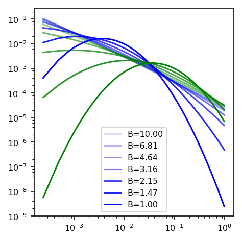

```python
x = np.linspace(1, 0, N, endpoint=False)[::-1]

def model(x, x_0, B):
    f =  1/x * np.exp( -.5 * np.log(x/x_0)**2 / B**2 )
    f /= f.sum()
    return f

ratio = 1
fig, ax = plt.subplots(1, 1, figsize=(fig_width/ratio, fig_width/ratio))
ax.axis(c='b', lw=2, axisbg='w')
ax.set_axis_bgcolor('w')

im_contrasts = 1. * np.logspace(-1, 0, 7)
for i_contrast, im_contrast in enumerate(im_contrasts):

    ax.loglog(x, model(x, x_0=.01, B=1./im_contrast), c='b', alpha=(i_contrast+1)/len(im_contrasts), label='B=%.2f' % (1./im_contrast))
    ax.loglog(x, model(x, x_0=.1, B=1./im_contrast), c='g', alpha=(i_contrast+1)/len(im_contrasts))

ax.legend(loc='best')
fig.tight_layout()
```

### Fitting

```
[[Variables]]
    x_0:   0.01000024 (init= 0.05)
    B:     1.00003388 (init= 0.15)
[[Correlations]] (unreported correlations are <  0.100)
```

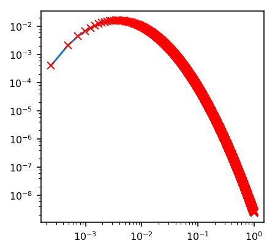

```python
import lmfit
from lmfit import Model
logN_mod = Model(model)
logN_mod.set_param_hint('x_0', value=0.05, min=0.)
logN_mod.set_param_hint('B', value=.15, min=0.)

proba = model(x, x_0=0.01, B=1.)
mi = logN_mod.fit(proba, x=x, method='Nelder')
#mi = lmfit.minimize(residual, p, args=(x, proba,), method='Nelder')
lmfit.printfuncs.report_fit(mi.params)#, min_correl=0.5)

fig, ax = plt.subplots(1, 1, figsize=(fig_width/ratio, fig_width/ratio))
ax.loglog(x, mi.best_fit)
ax.loglog(x, proba, 'rx')
```

## Power-law : Random sample generation

Random samples can be generated using inverse transform sampling. Given a random variate $U$ drawn from the uniform distribution on the unit interval $(0 1]$, the variate $T$ given by

$$ T=\frac{x_\mathrm{m}}{U^{\frac{1}{\alpha}}} $$

is Pareto-distributed

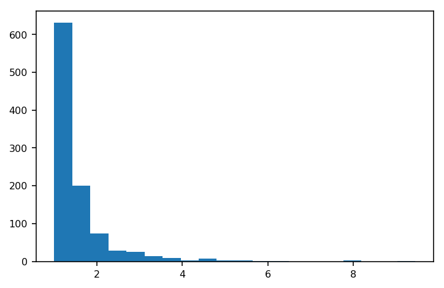

```python
#from scipy.stats import powerlaw
#r = 1. / powerlaw.rvs(a = 10, size = 1000)
a, m = 3., 1.  # shape and mode
r = (np.random.pareto(a, 1000) + 1) * m
_= plt.hist(r, bins=20)
```

```
0.22426766468
0.613125429432
0.76353855843
0.832208262458
0.870875591938
0.895610896843
```

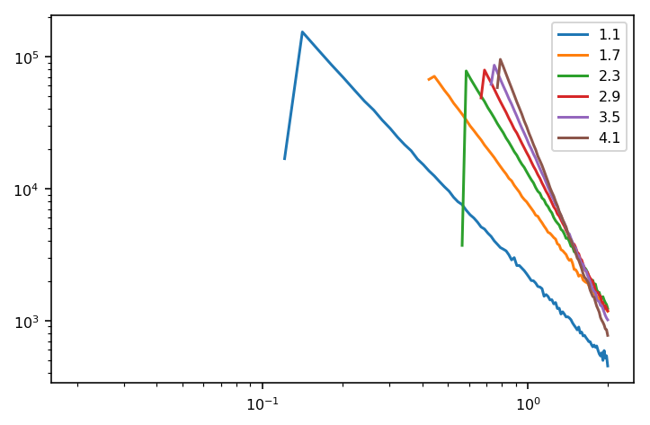

```python
N_sparse = 6
sparseness =  np.linspace(1.1, 4.1, N_sparse, endpoint=True)
N_edge = 1.e6

fig , ax = plt.subplots()
bins = np.linspace(1, 10, 100)
bins = np.linspace(0, 2, 100)
for a in sparseness:
    s =  (np.random.pareto(a=a, size=int(N_edge)) + 1) * m
    #s = 1/powerlaw.rvs(a=a, size = N_edge)
    s /= s.mean()
    hist, bins_ = np.histogram(s, bins=bins)
    ax.loglog(bins[1:], hist, label=a)
    print(np.median(s))
ax.legend()
```

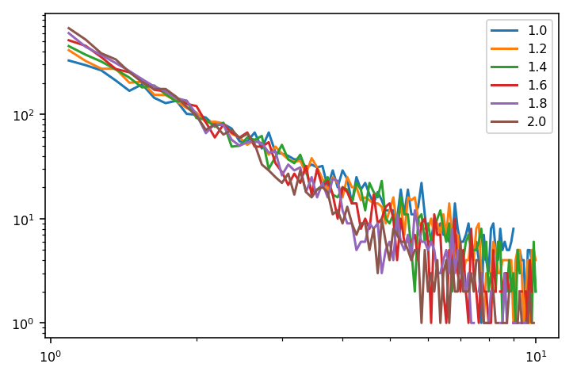

```python
from scipy.stats import powerlaw
N_sparse = 6
sparseness =  np.linspace(1., 2, N_sparse, endpoint=True)
N_edge = N

fig , ax = plt.subplots()
bins= np.linspace(1, 10, 100)
for a in sparseness:
    #s =  np.random.power(a=a, size=N_edge)
    s = np.random.pareto(a=a, size=(N_edge)) + 1
    #s = 1/powerlaw.rvs(a=a, size = N_edge)
    hist, bins_ = np.histogram(s, bins=bins)
    ax.loglog(bins[1:], hist, label=a)
ax.legend()
```

Now, we may also create new models by introducing a transition from the power-law to a Gaussian:

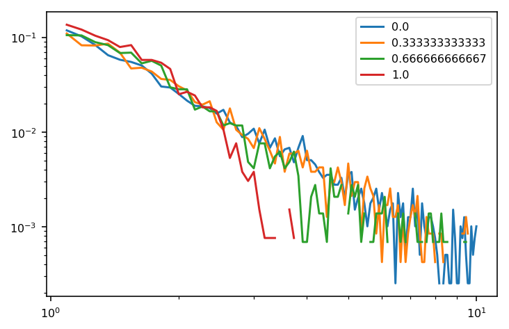

```python
N_noise = 4
a = 1.5
noises =  np.linspace(0., 1., N_noise, endpoint=True)

fig , ax = plt.subplots()
bins = np.linspace(1, 10, 100)
for noise in noises:
    s = (1-noise)*(np.random.pareto(a=a, size=(N_edge)) + 1)
    n = noise*np.random.randn(N_edge)
    hist, bins_ = np.histogram(np.abs(n+s), bins=bins, density=True)
    hist /= hist.sum()
    ax.loglog(bins[1:], hist, label=noise)
ax.legend();
```

## doing the fits on the *real* activation data

```python
imagelist, edgeslist, RMSE = mp.process(exp=experiment, name_database=name_database)
mp.pe.figpath = '../docs/'

value = edgeslist[4, ...].T
value /= RMSE[:, 0][:, np.newaxis]
RMSE /= RMSE[:, 0][:, np.newaxis]
RMSE = RMSE**2
N_image, N = RMSE.shape #number of images and edges
print(N_image, N )
```

```
100 4096
```

```python
a_min = value.min()
a_max = value.max()

#a_min = 10**-1.5
print('Min=', a_min, 'Max=', a_max, 'shape=', value.shape, 'Max=', value.max(axis=1))
```

```
Min= 3.3227408588e-05 Max= 0.0187982302149 shape= (100, 4096) Max= [ 0.0012  0.0023  0.0032  0.0025  0.0018  0.0081  0.009   0.0033  0.0026
  0.0039  0.0038  0.0026  0.0018  0.0024  0.0109  0.0188  0.0109  0.0077
  0.0036  0.0023  0.0031  0.0027  0.0034  0.0048  0.0031  0.0032  0.0029
  0.0025  0.0037  0.0062  0.0033  0.0027  0.0026  0.0032  0.0056  0.0061
  0.002   0.0081  0.0013  0.0025  0.0103  0.0036  0.0034  0.0049  0.005
  0.004   0.0034  0.003   0.0027  0.0017  0.0019  0.0028  0.0011  0.0026
  0.0026  0.0049  0.0041  0.0013  0.0021  0.0019  0.0018  0.0016  0.0033
  0.0026  0.0023  0.0031  0.0031  0.0034  0.0015  0.0029  0.0058  0.0049
  0.0012  0.0155  0.0023  0.0036  0.0067  0.0022  0.0039  0.0011  0.0105
  0.0017  0.0035  0.0034  0.0045  0.0035  0.0032  0.0033  0.0051  0.006
  0.0033  0.0013  0.0103  0.0033  0.006   0.0114  0.0073  0.004   0.0096
  0.0015]
```

```python
N_bins = 128
v_hist = np.zeros((N_image, N_bins))
bins = np.linspace(0, a_max, N_bins+1, endpoint=True)
bins = a_max*np.logspace(np.log10(a_min/a_max), 0, N_bins+1, endpoint=True, base=10)
print('bins used = ', bins, bins.shape)
for i_image in range(N_image):
    v_hist[i_image, : ], v_bins = np.histogram(value[i_image, :], bins=bins, density=True)
    #v_hist[i_image, : ], v_bins = np.histogram(value[i_image, :], bins=N_bins)
    v_hist[i_image, : ] /= v_hist[i_image, : ].sum()
v_middle = .5*(v_bins[1:]+v_bins[:-1])
```

```
bins used =  [ 0.      0.      0.      0.      0.      0.      0.      0.      0.
  0.0001  0.0001  0.0001  0.0001  0.0001  0.0001  0.0001  0.0001  0.0001
  0.0001  0.0001  0.0001  0.0001  0.0001  0.0001  0.0001  0.0001  0.0001
  0.0001  0.0001  0.0001  0.0001  0.0002  0.0002  0.0002  0.0002  0.0002
  0.0002  0.0002  0.0002  0.0002  0.0002  0.0003  0.0003  0.0003  0.0003
  0.0003  0.0003  0.0003  0.0004  0.0004  0.0004  0.0004  0.0004  0.0005
  0.0005  0.0005  0.0005  0.0006  0.0006  0.0006  0.0006  0.0007  0.0007
  0.0008  0.0008  0.0008  0.0009  0.0009  0.001   0.001   0.0011  0.0011
  0.0012  0.0012  0.0013  0.0014  0.0014  0.0015  0.0016  0.0017  0.0017
  0.0018  0.0019  0.002   0.0021  0.0022  0.0023  0.0025  0.0026  0.0027
  0.0029  0.003   0.0032  0.0033  0.0035  0.0037  0.0039  0.0041  0.0043
  0.0045  0.0047  0.0049  0.0052  0.0055  0.0057  0.006   0.0063  0.0066
  0.007   0.0073  0.0077  0.0081  0.0085  0.0089  0.0094  0.0099  0.0104
  0.0109  0.0115  0.012   0.0126  0.0133  0.014   0.0147  0.0154  0.0162
  0.017   0.0179  0.0188] (129,)
```

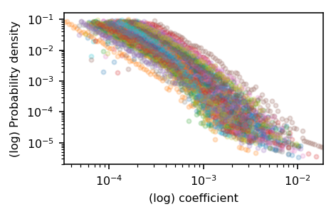

```python
fig, ax = plt.subplots(1, 1, figsize=(fig_width, fig_width/1.618), subplot_kw={'axisbg':'w'})

for i_image in range(N_image):
    valid = (v_hist[i_image, :] > 0.)
    ax.plot(v_middle[valid], v_hist[i_image, valid], '.', alpha=.2)
    #ax.plot(v_middle, v_hist[i_image, :], alpha=.2)
    ax.set_yscale('log')
    ax.set_xscale('log')
    ax.set_xlim(a_min, a_max)
    #ax.set_ylim(.0009, .05)
    ax.set_ylabel('(log) Probability density')
    ax.set_xlabel('(log) coefficient')

mp.savefig(fig, experiment + '_proba');
```

```python
from lmfit.models import ExpressionModel
mod = ExpressionModel('amplitude * x**-rho ')
def_vals = {'amplitude':1.e-6, 'rho':a}
weights = np.linspace(0, 1, N_bins)
weights = np.ones(N_bins)
weights = np.linspace(1, 0, N_bins)


#mod = ExpressionModel('amplitude * exp( - log(x)**2/rho**2 ) ')
#mod = ExpressionModel('amplitude * exp( - x/rho ) ')
verbose = False
amplitude, rho = np.zeros(N_image), np.zeros(N_image)
for i_image in range(N_image):
    mod.def_vals = def_vals
    valid = (v_hist[i_image, :] > 0.)
    #print(start, end)
    out  = mod.fit(v_hist[i_image, valid], x=v_middle[valid], verbose=verbose, weights=weights[valid])
    #print(out.fit_report())
    amplitude[i_image] = out.params.get('amplitude').value
    rho[i_image] =  out.params.get('rho').value
print ('amplitude=', amplitude.mean(), ', +/- ', amplitude.std())
print ('rho=', rho.mean(), ', +/- ', rho.std())
```

```
amplitude= 2.85238179461e-07 , +/-  3.6470296012e-07
rho= 1.4697728071 , +/-  0.169105803531
```

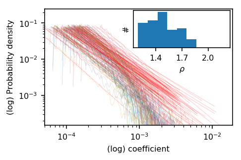

```python
start = 10
#fig, ax = plt.subplots(1, 1, figsize=(fig_width/2, fig_width/2), subplot_kw={'axisbg':'w'})
fig = plt.figure(figsize=(fig_width, fig_width/1.618))

ax = fig.add_axes([0.2, 0.2, .78, .78], axisbg='w')
for i_image in range(N_image):
    #ax.plot(v_middle[start:], v_hist[i_image, start:], '-', alpha=.1, lw=.5)
    params = mod.make_params(amplitude=amplitude[i_image], rho=rho[i_image])
    valid = (v_hist[i_image, :] > 0.)
    ax.plot(v_middle[valid], v_hist[i_image, valid], '-', alpha=.2, lw=.5)
    ax.plot(v_middle[valid], mod.eval(params, x=v_middle[valid]), 'r', alpha=.2, lw=.5)
    ax.set_yscale('log')
    ax.set_xscale('log')
    #ax.set_xticks([])
    #ax.set_yticks([])
    ax.axis('tight')
    ax.set_xlim(a_min*1.5, a_max)
    ax.set_ylim(.00015, .25)
    ax.set_ylabel('(log) Probability density')
    ax.set_xlabel('(log) coefficient')


inset = fig.add_axes([0.57, 0.72, .4, .25], axisbg='w')
inset.hist(np.abs(rho), bins=np.linspace(1.2, 2.2, 10))
inset.axis('tight')
_ = inset.set_ylabel('')
_ = inset.set_yticks([])
_ = inset.set_xticks([1.4, 1.7, 2.0])
inset.set_ylabel('#')# occurences')
inset.set_xlabel(r'$\rho$');
```

### Pareto

That is, by the probability density function

$$ f_X(x)= \begin{cases} \frac{\alpha x_\mathrm{m}^\alpha}{x^{\alpha+1}} & x \ge x_\mathrm{m}, \\ 0 & x < x_\mathrm{m}. \end{cases} $$

where xm is the (necessarily positive) minimum possible value of X, and α is a positive parameter.

#### computing histograms

```python
imagelist, edgeslist, RMSE = mp.process(exp=experiment, name_database=name_database)
value = edgeslist[4, ...].T
```

```python
#value /= value[:, 0][:, np.newaxis]
#value /= value.max(axis=1)[:, np.newaxis]
value /= value.min(axis=1)[:, np.newaxis]
#value /= value.mean(axis=1)[:, np.newaxis]

N_image, N = value.shape #number of images x edges

N_bins = 128
a_min = value.min()
a_max = value.max()

#a_min = 10**-1.5
print(a_min, a_max, value.shape, value.max(axis=1))
```

```
1.0 173.379919218 (100, 4096) [  10.4577   15.1586   24.3496   17.9788   21.8645   73.1106   85.5869
   31.1506   17.2071   64.6511   35.6902   20.0014    9.3748   14.0285
   78.9176   66.4866  130.8953  118.6719   26.7659   16.9365   35.0172
   21.0048   38.5452   24.8051   48.741    22.3939   35.2257   17.2325
   27.1678   53.895    17.7627   22.8225   17.557    25.2496   25.5308
   52.2553   12.295    75.1646   18.7658   17.8997  173.3799  107.8868
   32.9144   20.2638   40.881    29.4651   29.7318   21.4937   47.6966
   24.7363   15.1702   31.279    12.925    15.1139   15.5841   51.1507
   35.7175   27.8074   16.9295   28.5136   17.4394   25.0073   49.4687
   16.4457   16.244    47.1501   33.0998   24.1733   14.839    32.1438
   81.5193   48.3521   12.4568  133.7688   21.7698   23.4281   65.4728
   24.0196   29.1722    9.335    56.2236   13.5169   24.4192   36.92
   92.2809   30.1319   26.4825   45.7744   73.2493   40.5278   34.1047
    8.5025   62.7278   44.9286   38.2382   70.5242   35.512    44.0372
   50.8088   12.5882]
```

```python
v_hist = np.zeros((N_image, N_bins))
bins = np.linspace(0, a_max, N_bins+1, endpoint=True)#[:-1]
bins = a_max*np.logspace(np.log10(a_min/a_max), 0, N_bins+1, endpoint=True)#[:-1]
#print(bins.shape)
for i_image in range(N_image):
    v_hist[i_image, : ], v_bins = np.histogram(value[i_image, :], bins=bins, density=True)
    #v_hist[i_image, : ], v_bins = np.histogram(value[i_image, :], bins=N_bins)
    v_hist[i_image, : ] /= v_hist[i_image, : ].sum()
v_middle = .5*(v_bins[1:]+v_bins[:-1])
```

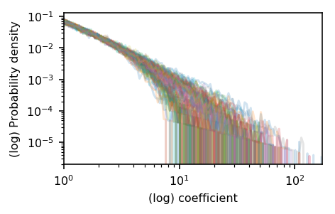

```python
fig, ax = plt.subplots(1, 1, figsize=(fig_width, fig_width/1.618), subplot_kw={'axisbg':'w'})

for i_image in range(N_image):
    ax.plot(v_middle, v_hist[i_image, :], alpha=.2)
    ax.set_yscale('log')
    ax.set_xscale('log')
    ax.set_xlim(a_min, a_max)
    #ax.set_ylim(.0009, .05)
    ax.set_ylabel('(log) Probability density')
    ax.set_xlabel('(log) coefficient')

#mp.savefig(fig, experiment + '_proba');
```

#### log-normal

```
A= 6.98070066648 , +/-  26.3717544855
x_0= 0.473737056247 , +/-  0.302995633087
B= 1.71184603041 , +/-  1.06576019489
```

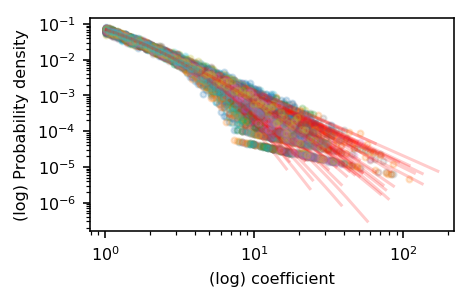

```python
import lmfit
from lmfit import Model

def model(x, A, x_0, B):
    f =  A / x * np.exp( -.5 * np.log(x/x_0)**2 / B**2 )
    #f /= f.sum()
    return f

weights = np.linspace(0, 1, N_bins)
weights = np.linspace(1, 0, N_bins)
weights = np.ones(N_bins)
verbose = False

A, x_0, B = np.zeros(N_image), np.zeros(N_image), np.zeros(N_image)
for i_image in range(N_image):
    mod = Model(model)
    mod.set_param_hint('A', value=.05, min=0.)
    #mod.set_param_hint('x_0', value=.45, min=0.45, max=0.46)
    mod.set_param_hint('x_0', value=.5, min=0.)
    mod.set_param_hint('B', value=1.9, min=0.)

    valid = (v_hist[i_image, :] > 0.)
    out  = mod.fit(v_hist[i_image, valid], x=v_middle[valid],
                   verbose=verbose, weights=weights[valid], method='leastsq', maxfev=1e6)
    if verbose: print(out.fit_report())
    A[i_image] = out.params.get('A').value
    x_0[i_image] =  out.params.get('x_0').value
    B[i_image] =  out.params.get('B').value
print ('A=', A.mean(), ', +/- ', A.std())
print ('x_0=', x_0.mean(), ', +/- ', x_0.std())
print ('B=', B.mean(), ', +/- ', B.std())

fig, ax = plt.subplots(1, 1, figsize=(fig_width, fig_width/1.618), subplot_kw={'axisbg':'w'})
for i_image in range(N_image):
    ax.plot(v_middle[valid], v_hist[i_image, valid], '.', alpha=.2)
    valid = (v_hist[i_image, :] > 0.)
    #params = mod.make_params(A=A[i_image], x_0=x_0[i_image], B=B[i_image])
    #ax.plot(v_middle[valid], mod.eval(params, x=v_middle[valid]), 'r', alpha=.2)
    ax.plot(v_middle[valid], model(v_middle[valid], A=A[i_image], x_0=x_0[i_image], B=B[i_image]), 'r', alpha=.2)
    ax.set_yscale('log')
    ax.set_xscale('log')
    ax.axis('tight')
    #ax.set_xlim(a_min, a_max)
    #ax.set_ylim(.0003, .1)
    ax.set_ylabel('(log) Probability density')
    ax.set_xlabel('(log) coefficient')

#mp.savefig(fig, experiment + '_proba');
```

#### gamma

https://en.wikipedia.org/wiki/Gamma_distribution

```
A= 0.106767287774 , +/-  0.0184238611366
x_0= 2.45957632082 , +/-  0.638109293316
k= 0.0603033681388 , +/-  0.148884665643
```

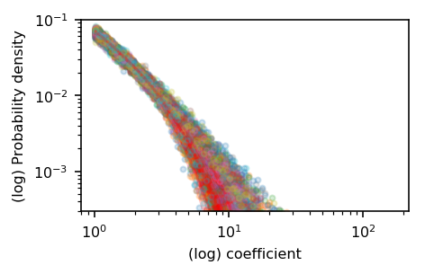

```python
import lmfit
from lmfit import Model

def model(x, A, k, x_0):
    f =  A * x **(k-1) * np.exp( - x/x_0)
    #f /= f.sum()
    return f

weights = np.linspace(0, 1, N_bins)
weights = np.linspace(1, 0, N_bins)
weights = np.ones(N_bins)
verbose = False

A, x_0, k = np.zeros(N_image), np.zeros(N_image), np.zeros(N_image)
for i_image in range(N_image):
    mod = Model(model)
    mod.set_param_hint('A', value=.05, min=0.)
    #mod.set_param_hint('x_0', value=.45, min=0.45, max=0.46)
    mod.set_param_hint('x_0', value=5.5, min=0.)
    mod.set_param_hint('k', value=.9, min=0.)

    valid = (v_hist[i_image, :] > 0.)
    out  = mod.fit(v_hist[i_image, valid], x=v_middle[valid],
                   verbose=verbose, weights=weights[valid], method='leastsq', maxfev=1e6)
    if verbose: print(out.fit_report())
    A[i_image] = out.params.get('A').value
    x_0[i_image] =  out.params.get('x_0').value
    k[i_image] =  out.params.get('k').value
print ('A=', A.mean(), ', +/- ', A.std())
print ('x_0=', x_0.mean(), ', +/- ', x_0.std())
print ('k=', k.mean(), ', +/- ', k.std())

fig, ax = plt.subplots(1, 1, figsize=(fig_width, fig_width/1.618), subplot_kw={'axisbg':'w'})
for i_image in range(N_image):
    ax.plot(v_middle[valid], v_hist[i_image, valid], '.', alpha=.2)
    valid = (v_hist[i_image, :] > 0.)
    #params = mod.make_params(A=A[i_image], x_0=x_0[i_image], B=B[i_image])
    #ax.plot(v_middle[valid], mod.eval(params, x=v_middle[valid]), 'r', alpha=.2)
    ax.plot(v_middle[valid], model(v_middle[valid], A=A[i_image], x_0=x_0[i_image], k=k[i_image]), 'r', alpha=.2)
    ax.set_yscale('log')
    ax.set_xscale('log')
    ax.axis('tight')
    #ax.set_xlim(a_min, a_max)
    ax.set_ylim(.0003, .1)
    ax.set_ylabel('(log) Probability density')
    ax.set_xlabel('(log) coefficient')

#mp.savefig(fig, experiment + '_proba');
```

```python
import lmfit
from lmfit import Model

def model(x, A, x_0, B):
    f =  A / x * np.exp( -.5 * np.log(1+x/x_0)**2 / B**2 )
    #f /= f.sum()
    return f
```

```
A= 7.13409519973 , +/-  27.4956110386
x_0= 0.998582623908 , +/-  1.3547272191
B= 1.56356878844 , +/-  1.16482501949
```

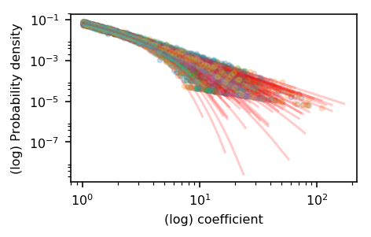

```python
weights = np.linspace(0, 1, N_bins)
weights = np.linspace(1, 0, N_bins)
weights = np.ones(N_bins)
verbose = False

A, x_0, B = np.zeros(N_image), np.zeros(N_image), np.zeros(N_image)
for i_image in range(N_image):
    mod = Model(model)
    mod.set_param_hint('A', value=.05, min=0.)
    #mod.set_param_hint('x_0', value=.45, min=0.45, max=0.46)
    mod.set_param_hint('x_0', value=.5, min=0.)
    mod.set_param_hint('B', value=1.7, min=0.)

    valid = (v_hist[i_image, :] > 0.)
    out  = mod.fit(v_hist[i_image, valid], x=v_middle[valid],
                   verbose=verbose, weights=weights[valid], method='leastsq', maxfev=1e6)
    if verbose: print(out.fit_report())
    A[i_image] = out.params.get('A').value
    x_0[i_image] =  out.params.get('x_0').value
    B[i_image] =  out.params.get('B').value
print ('A=', A.mean(), ', +/- ', A.std())
print ('x_0=', x_0.mean(), ', +/- ', x_0.std())
print ('B=', B.mean(), ', +/- ', B.std())

fig, ax = plt.subplots(1, 1, figsize=(fig_width, fig_width/1.618), subplot_kw={'axisbg':'w'})
for i_image in range(N_image):
    ax.plot(v_middle[valid], v_hist[i_image, valid], '.', alpha=.2)
    valid = (v_hist[i_image, :] > 0.)
    #params = mod.make_params(A=A[i_image], x_0=x_0[i_image], B=B[i_image])
    #ax.plot(v_middle[valid], mod.eval(params, x=v_middle[valid]), 'r', alpha=.2)
    ax.plot(v_middle[valid], model(v_middle[valid], A=A[i_image], x_0=x_0[i_image], B=B[i_image]), 'r', alpha=.2)
    ax.set_yscale('log')
    ax.set_xscale('log')
    ax.axis('tight')
    #ax.set_xlim(a_min, a_max)
    #ax.set_ylim(.0003, .1)
    ax.set_ylabel('(log) Probability density')
    ax.set_xlabel('(log) coefficient')

#mp.savefig(fig, experiment + '_proba')
```

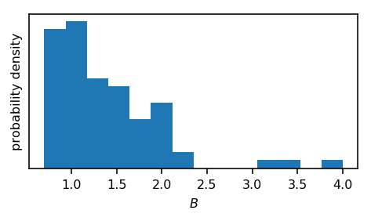

```python
fig, axs = plt.subplots(1, 1, figsize=(fig_width, fig_width/1.618), subplot_kw={'axisbg':'w'})

axs.hist(B, bins=np.linspace(.7, 4., 15))
axs.axis('tight')
_ = axs.set_ylabel('')
_ = axs.set_yticks([])
axs.set_ylabel('probability density')
axs.set_xlabel(r'$B$')
fig.tight_layout()
#mp.savefig(fig, experiment + '_fit_hist')
```

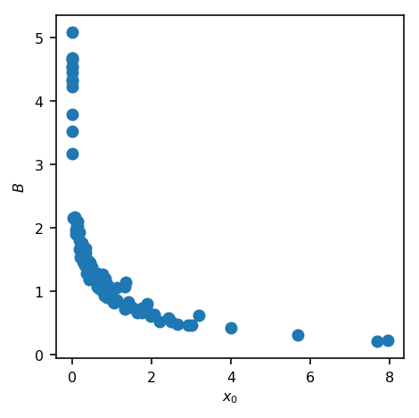

```python
fig, axs = plt.subplots(1, 1, figsize=(fig_width, fig_width), subplot_kw={'axisbg':'w'})

axs.scatter(x_0, B)
axs.axis('tight')
axs.set_xlabel(r'$x_0$')
axs.set_ylabel(r'$B$')
fig.tight_layout()
```

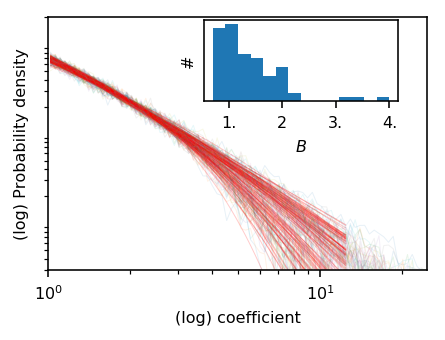

```python
start = 10
#fig, ax = plt.subplots(1, 1, figsize=(fig_width/2, fig_width/2), subplot_kw={'axisbg':'w'})
#fig = plt.figure(figsize=(fig_width, fig_width/1.618))
fig = plt.figure(figsize=(fig_width, fig_width/1.5))


ax = fig.add_axes([0.2, 0.2, .78, .78], axisbg='w')
for i_image in range(N_image):
    ax.plot(v_middle, v_hist[i_image, :], '-', alpha=.1, lw=.5)
    ax.plot(v_middle[valid], model(v_middle[valid], A=A[i_image], x_0=x_0[i_image], B=B[i_image]),
            'r', alpha=.2, lw=.5)

    ax.set_yscale('log')
    ax.set_xscale('log')
    #ax.set_xticks([])
    ax.set_yticks([])
    ax.axis('tight')
    ax.set_xlim(a_min, a_max/7)
    ax.set_ylim(.0003, .2)
    ax.set_ylabel('(log) Probability density')
    ax.set_xlabel('(log) coefficient')

inset = fig.add_axes([0.52, 0.72, .4, .25], axisbg='w')
inset.hist(B, bins=np.linspace(.7, 4., 15))

inset.axis('tight')
_ = inset.set_ylabel('')
_ = inset.set_yticks([])
_ = inset.set_xticks([1., 2., 3., 4.])
_ = inset.set_xticklabels(["1.", "2", "3.", "4."], fontdict={'fontsize':8})
inset.set_ylabel('#')# occurences')
inset.set_xlabel(r'$B$')

#fig.subplots_adjust(left=0.22, bottom=0.1, right=.9, top=.9)
#mp.savefig(fig, experiment + '_proba_inset')
```

#### power-law

```
A= 0.072395145965 , +/-  0.00459089239196
rho= 1.73816009159 , +/-  0.107339062288
```

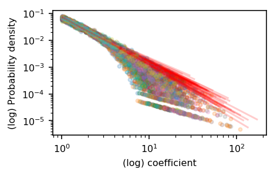

```python
import lmfit
from lmfit import Model

def model(x, A, rho):
    f =  A / x ** rho
    #f /= f.sum()
    return f

weights = np.linspace(1, 0, N_bins)
weights = np.linspace(0, 1, N_bins)
weights = np.ones(N_bins)
verbose = False

A, rho = np.zeros(N_image), np.zeros(N_image)
for i_image in range(N_image):
    mod = Model(model)
    mod.set_param_hint('A', value=.05, min=0.)
    mod.set_param_hint('rho', value=2.5, min=1.)

    valid = (v_hist[i_image, :] > 0.)
    out  = mod.fit(v_hist[i_image, valid], x=v_middle[valid],
                   verbose=verbose, weights=weights[valid], method='leastsq', maxfev=1e6)
    if verbose: print(out.fit_report())
    A[i_image] = out.params.get('A').value
    rho[i_image] =  out.params.get('rho').value
print ('A=', A.mean(), ', +/- ', A.std())
print ('rho=', rho.mean(), ', +/- ', rho.std())

fig, ax = plt.subplots(1, 1, figsize=(fig_width, fig_width/1.618), subplot_kw={'axisbg':'w'})
for i_image in range(N_image):
    ax.plot(v_middle[valid], v_hist[i_image, valid], '.', alpha=.2)
    valid = (v_hist[i_image, :] > 0.)
    ax.plot(v_middle[valid], model(v_middle[valid], A=A[i_image], rho=rho[i_image]), 'r', alpha=.2)
    ax.set_yscale('log')
    ax.set_xscale('log')
    ax.axis('tight')
    ax.set_ylabel('(log) Probability density')
    ax.set_xlabel('(log) coefficient')

#mp.savefig(fig, experiment + '_proba')
```

```python
from lmfit.models import ExpressionModel
mod = ExpressionModel('amplitude * x**-rho ')
def_vals = {'amplitude':.1, 'rho':1.5}
weights = np.linspace(1, 0, N_bins)
weights = np.ones(N_bins)

#mod = ExpressionModel('amplitude * exp( - log(x)**2/rho**2 ) ')
#mod = ExpressionModel('amplitude * exp( - x/rho ) ')
verbose = False
amplitude, rho = np.zeros(N_image), np.zeros(N_image)
for i_image in range(N_image):
    #pars = mod.guess(RMSE[i_image, :], x=np.arange(N))
    mod.def_vals = def_vals
    valid = (v_hist[i_image, :] > 0.)
    #print(start, end)
    out  = mod.fit(v_hist[i_image, valid], x=v_middle[valid], verbose=verbose, weights=weights[valid])
    #print(out.fit_report())
    amplitude[i_image] = out.params.get('amplitude').value
    rho[i_image] =  out.params.get('rho').value
print ('rho=', rho.mean(), ', +/- ', rho.std())
```

```
rho= 1.73815985178 , +/-  0.107339520413
```

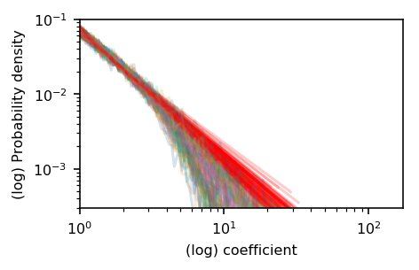

```python
fig, ax = plt.subplots(1, 1, figsize=(fig_width, fig_width/1.618), subplot_kw={'axisbg':'w'})

for i_image in range(N_image):
    ax.plot(v_middle, v_hist[i_image, :], alpha=.2)
    params = mod.make_params(amplitude=amplitude[i_image], rho=rho[i_image])
    valid = (v_hist[i_image, :] > 0.)
    ax.plot(v_middle[valid], mod.eval(params, x=v_middle[valid]), 'r', alpha=.2)
    ax.set_yscale('log')
    ax.set_xscale('log')
    ax.axis('tight')
    ax.set_xlim(a_min, a_max)
    ax.set_ylim(.0003, .1)
    ax.set_ylabel('(log) Probability density')
    ax.set_xlabel('(log) coefficient')
#mp.savefig(fig, experiment + '_proba')
```

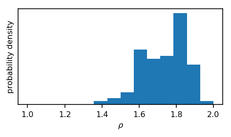

```python
fig, axs = plt.subplots(1, 1, figsize=(fig_width, fig_width/1.618), subplot_kw={'axisbg':'w'})

axs.hist(np.abs(rho), bins=np.linspace(1., 2., 15))
axs.axis('tight')
_ = axs.set_ylabel('')
_ = axs.set_yticks([])
axs.set_ylabel('probability density')
axs.set_xlabel(r'$\rho$')
fig.tight_layout()
#mp.savefig(fig, experiment + '_fit_hist')
```

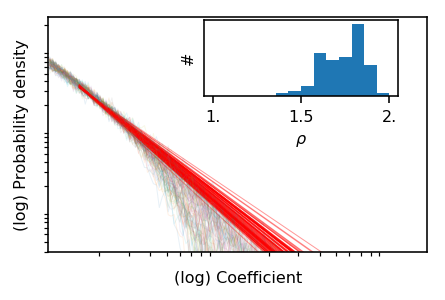

```python
start = 10
#fig, ax = plt.subplots(1, 1, figsize=(fig_width/2, fig_width/2), subplot_kw={'axisbg':'w'})
fig = plt.figure(figsize=(fig_width, fig_width/1.618))

ax = fig.add_axes([0.2, 0.2, .78, .78], axisbg='w')
for i_image in range(N_image):
    ax.plot(v_middle, v_hist[i_image, :], '-', alpha=.1, lw=.5)
    params = mod.make_params(amplitude=amplitude[i_image], rho=rho[i_image])
    ax.plot(v_middle[start:], mod.eval(params, x=v_middle[start:]), 'r', alpha=.4, lw=.5)
    ax.set_yscale('log')
    ax.set_xscale('log')
    ax.set_xticks([])
    ax.set_yticks([])
    ax.axis('tight')
    ax.set_xlim(a_min, a_max)
    ax.set_ylim(.0003, .25)
    ax.set_ylabel('(log) Probability density')
    ax.set_xlabel('(log) Coefficient')

inset = fig.add_axes([0.52, 0.72, .4, .25], axisbg='w')
inset.hist(rho, bins=np.linspace(1., 2., 15))
inset.axis('tight')
_ = inset.set_ylabel('')
_ = inset.set_yticks([])
_ = inset.set_xticks([1., 1.5, 2.])
_ = inset.set_xticklabels(["1.", "1.5", "2."], fontdict={'fontsize':8})
inset.set_ylabel('#')# occurences')
inset.set_xlabel(r'$\rho$')

#fig.subplots_adjust(left=0.22, bottom=0.1, right=.9, top=.9)
mp.savefig(fig,  experiment + '_proba_inset');
```

## fitting the error function

To check the previous result, we also fit the error function and sorted coefficients. These are linked by the following relation:

Let's define the point non-linearity $z_i$ applied to the sparse coefficients $a_i$ to achieve uniformity by using an equalization of the histogram. This method may be easily derived if we know the probability distribution function $dP_{i}$ of variable $a_i$ by choosing the non-linearity as the cumulative distribution function transforming any observed variable $\bar{a}_i$ into: $$ z_i(\bar{a}_i)= P_{i}(a_i \leq \bar{a}_i) = \int_{-\infty}^{\bar{a}_i} dP_{i}(a_i)% $$ This is equivalent to the change of variables which transforms the sparse vector $a_i$ to a variable with uniform probability distribution function in $[0, 1]$. This equalization process has been observed in the neural activity of a variety of species and is, for instance, perfectly illustrated in the salamander's retina (Laughlin, 81). It may evolve dynamically to slowly adapt to varying changes in luminance or contrast values, such as when the light diminishes at twilight (Hosoya, 05).

In practice, the $z_i$ functions may be initialized to similar arbitrary cumulative distribution functions. Since at each measure, we have one sparse value $a_i$, the cumulative histogram function is $P(a_i \leq \bar{a}_i) = \delta(a_i \leq \bar{a}_i)$ where variable $\bar{a}_i$ is the observed coefficient to be transformed and $\delta$ is the Dirac measure: $\delta(B)=1$ if the boolean variable $B$ is true and $0$ otherwise. We may thus evaluate $P$ after the end of every coding using an online stochastic algorithm, $\forall i, \forall \bar{a}_i$: $$ z_i( \bar{a}_i ) \leftarrow (1- \eta_h ) z_i( \bar{a}_i ) + \eta_h \delta(a_i \leq \bar{a}_i)% $$ where $\eta_h$ is an homeostatic learning rate. Note that this corresponds to the empirical estimation and assumes that coefficients are stationary on a time scale of $\frac{1}{\eta_{h}}$ learning steps.

Conversely, we may write as $\frac{r}{M}$ the relative rank of the $r^{th}$ and $o$ the order function which gives the address of the coefficient of rank $r$. Since $z_{o(r)}= 1- \frac{r}{M} = z_{o(r)}(a_{o(r)})$, we can reconstruct the corresponding value as% $$ \hat{a}_{o(r)} = z_{o(r)}^{-1}(1- \frac{r}{M} )% $$ In fact, this scheme is rather general and is analogous to scalar quantization using the modulation function $z_i^{-1}$ as a Look-up-Table.

```python
!pip3 install -U lmfit
```

```python
imagelist, edgeslist, RMSE = mp.process(exp=experiment, name_database=name_database)
value = edgeslist[4, ...].T
value /= RMSE[:, 0][:, np.newaxis]
RMSE /= RMSE[:, 0][:, np.newaxis]
RMSE = RMSE**2
N_image, N = RMSE.shape #number of images x edges
```

```
rho= 0.989297022078 , +/-  0.00876014263426
```

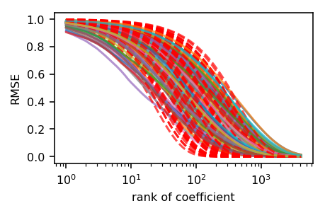

```python
from lmfit.models import ExpressionModel
mod = ExpressionModel('rho**x')
def_vals = {'rho':.98}
verbose = False
weights = 1
weights = 1/np.sqrt(np.arange(N)+1)

fig, ax = plt.subplots(1, 1, figsize=(fig_width, fig_width/1.618), subplot_kw={'axisbg':'w'})
rho = np.zeros(N_image)
for i_image in range(N_image):
    mod.def_vals = def_vals
    out  = mod.fit(RMSE[i_image, :], x=np.arange(N), verbose=verbose, weights=weights)
    rho[i_image] =  out.params.get('rho').value
    params = mod.make_params(rho=rho[i_image])
    ax.semilogx( RMSE[i_image, :], alpha=.7)
    ax.semilogx(mod.eval(params, x=np.arange(N)), 'r--', alpha=.7)
    ax.set_xlabel('rank of coefficient')
    ax.axis('tight')
    _ = ax.set_ylabel('RMSE')

print ('rho=', rho.mean(), ', +/- ', rho.std())
```

```
rho= 0.996789602963 , +/-  0.0
```

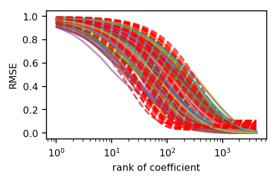

```python
mod = ExpressionModel('1 - (1- eps_inf) * ( 1 - rho**(x+1))')
def_vals = {'eps_inf':.001, 'rho':.996}
verbose = False
weights = 1/np.sqrt(np.arange(N)+1)

fig, ax = plt.subplots(1, 1, figsize=(fig_width, fig_width/1.618), subplot_kw={'axisbg':'w'})
for i_image in range(N_image):
    mod.def_vals = def_vals
    out  = mod.fit(RMSE[i_image, :], x=np.arange(N), verbose=verbose, weights=weights)
    eps_inf = out.params.get('eps_inf').value
    rho =  out.params.get('rho').value
    params = mod.make_params(eps_inf=eps_inf, rho=rho)
    ax.semilogx( RMSE[i_image, :], alpha=.7)
    ax.semilogx(mod.eval(params, x=np.arange(N)), 'r--', alpha=.7)
    ax.set_xlabel('rank of coefficient')
    ax.axis('tight')
    _ = ax.set_ylabel('RMSE')

print ('rho=', rho.mean(), ', +/- ', rho.std())
```

```python
%cd -q ../notebooks/
```